# M1E-4410 性能評価およびチューブ閉塞分析レポート

Ryuta

2026-08-31

# 目的

M1粗MAA分離塔リボイラー（M1E-4410）の詰まり本数と各運転パラメータ（U値、ジャケット圧、ポンプ圧）の相関関係を分析し、詰まりの発生要因を特定することを目的とする。

## データ読み込み

### 時系列データ

|  | Timestamp | U | jacket_P | pump_outlet | Period |
| --- | --- | --- | --- | --- | --- |
| 1 | 2021-03-13T00:00:00Z | 1275.275698443719 | -9.202721 | -3.103179 | 2103 |
| 2 | 2021-03-14T00:00:00Z | 1304.028867367967 | -9.564683 | -3.675009 | 2103 |
| 3 | 2021-03-15T00:00:00Z | 1289.887647197526 | -9.485353 | -3.557779 | 2103 |
| 4 | 2021-03-16T00:00:00Z | 1184.054029638538 | -7.229238 | -2.746351 | 2103 |
| 5 | 2021-03-17T00:00:00Z | 1158.032113496352 | -7.27095 | -2.775208 | 2103 |
| 6 | 2021-03-18T00:00:00Z | 1202.18090859881 | -7.32387 | -2.941561 | 2103 |
| 7 | 2021-03-19T00:00:00Z | 1153.585983259407 | -7.076692 | -2.927538 | 2103 |
| 8 | 2021-03-20T00:00:00Z | 1111.149922944605 | -6.233747 | -2.619566 | 2103 |
| 9 | 2021-03-21T00:00:00Z | 1008.515380326109 | -5.382868 | -1.368612 | 2103 |
| 10 | 2021-03-22T00:00:00Z | 1084.613806797815 | -6.336282 | -2.356694 | 2103 |

[output cut: 681 more lines]

### 詰まりデータ

|  | U | 詰まり本数 | PI | Flow | Timestamp | Period | production | jacket_P | b/e | PeriodType |
| --- | --- | --- | --- | --- | --- | --- | --- | --- | --- | --- |
| 1 |  | 16 |  |  | 2021-09-08 00:00:00 | 2103 |  |  | End | 2103_End |
| 2 |  | 46 |  |  | 2022-04-13 00:00:00 | 2109 |  |  | End | 2109_End |
| 3 |  | 50 |  |  | 2022-10-15 00:00:00 | 2206 |  |  | End | 2206_End |
| 4 |  | 75 |  |  | 2023-04-01 00:00:00 | 2302 |  |  | End | 2302_End |
| 5 |  | 212 |  |  | 2025-06-30 00:00:00 | 2404 |  |  | End | 2404_End |

## パラメータ推移

各パラメータ（U値、ジャケット圧、ポンプ圧）の推移を時系列グラフで確認する。

### U値

[interactive chart not shown]

### ジャケット圧

[interactive chart not shown]

### ポンプ圧

[interactive chart not shown]

## データ加工と分析

各パラメータ（U値、ジャケット圧、ポンプ圧）について、キャンペーンの初期・末期の最大値を抽出し、詰まり本数（NoS）との相関を分析する。

### Case1) UA

U値の最大値からUAを算出し、相関を確認する。

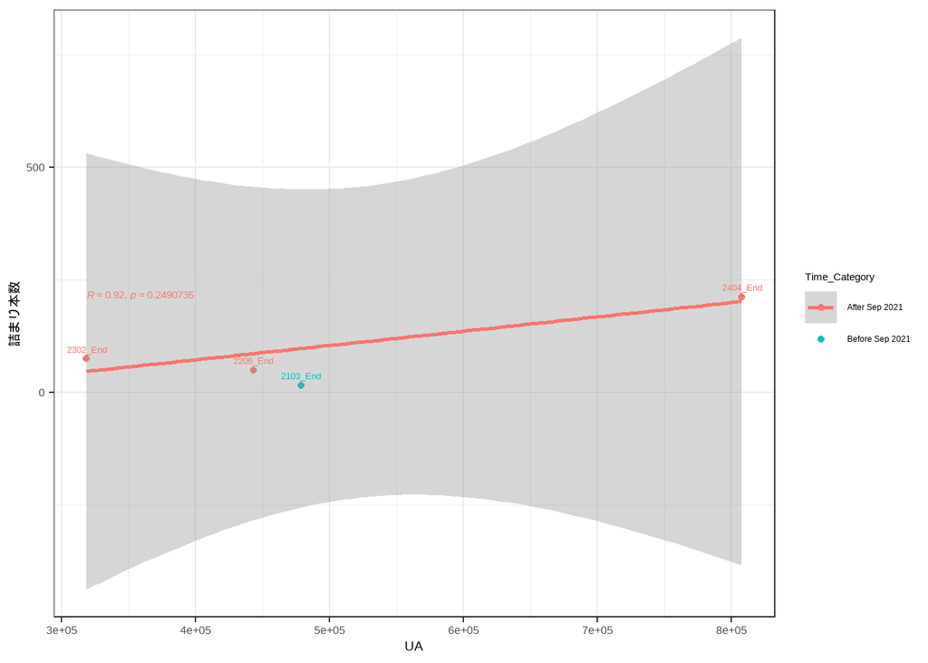

```
##
## Call:
## lm(formula = y_val ~ x_val)
##
## Residuals:
##      1      2      3      4
## -60.95 -14.95  52.16  23.74
##
## Coefficients:
##               Estimate Std. Error t value Pr(>|t|)
## (Intercept) -8.489e+01  9.024e+01  -0.941    0.446
## x_val        3.382e-04  1.662e-04   2.035    0.179
##
## Residual standard error: 60.09 on 2 degrees of freedom
## Multiple R-squared:  0.6743, Adjusted R-squared:  0.5114
## F-statistic:  4.14 on 1 and 2 DF,  p-value: 0.1788
```

### Case2) ジャケット圧

ジャケット圧（jacket_P）の最大値と詰まり本数の相関を確認する。

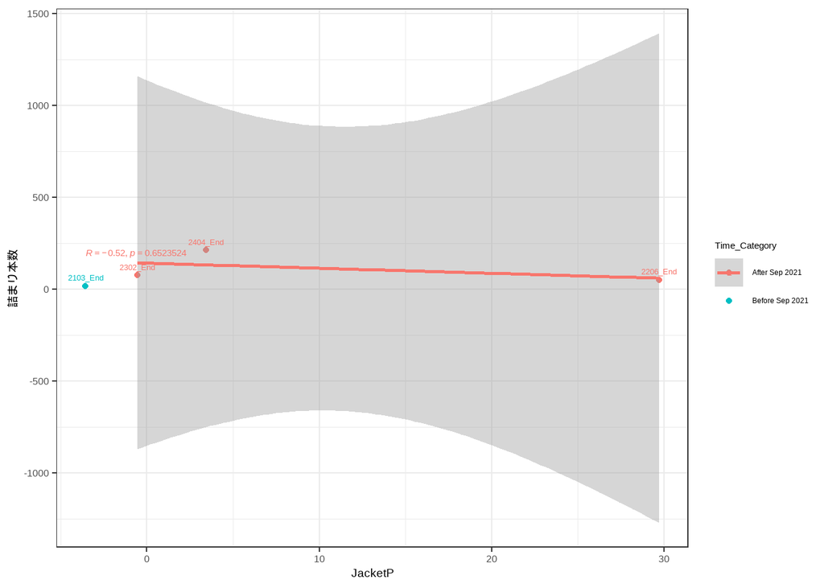

```
##
## Call:
## lm(formula = y_val ~ x_val)
##
## Residuals:
##      1      2      3      4
## -79.19 -23.86 -18.25 121.30
##
## Coefficients:
##             Estimate Std. Error t value Pr(>|t|)
## (Intercept)  92.8996    59.6869   1.556    0.260
## x_val        -0.6406     3.9614  -0.162    0.886
##
## Residual standard error: 104.6 on 2 degrees of freedom
## Multiple R-squared:  0.01291,    Adjusted R-squared:  -0.4806
## F-statistic: 0.02615 on 1 and 2 DF,  p-value: 0.8864
```

### Case3) ポンプ圧

ポンプ吐出圧（pump_outlet）の最大値と詰まり本数の相関を確認する。

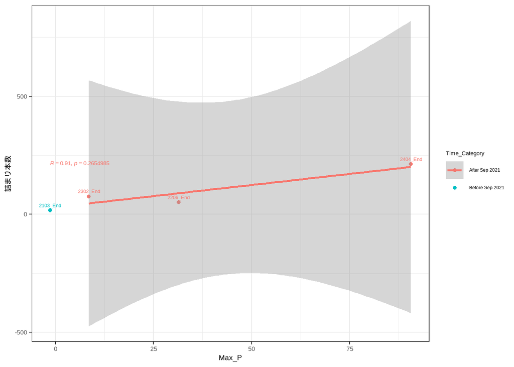

```
##
## Call:
## lm(formula = y_val ~ x_val)
##
## Residuals:
##       1       2       3       4
##  -6.253 -36.488  33.333   9.408
##
## Coefficients:
##             Estimate Std. Error t value Pr(>|t|)
## (Intercept)  24.9355    24.1671   1.032   0.4106
## x_val         1.9602     0.5019   3.906   0.0597 .
## ---
## Signif. codes:  0 '***' 0.001 '**' 0.01 '*' 0.05 '.' 0.1 ' ' 1
##
## Residual standard error: 35.85 on 2 degrees of freedom
## Multiple R-squared:  0.8841, Adjusted R-squared:  0.8261
## F-statistic: 15.25 on 1 and 2 DF,  p-value: 0.05974
```

### 乖離幅の分析まとめ

予測式との乖離幅が最も大きいプロットについて、全体本数（1064本）に対する割合を以下に示す。

[output not shown]